# 파이썬의 대표적 데이터 시각화 모듈 - Matplotlib

많은 내용들이 Matplotlib 모듈에 포함 되어 있지만, 우리는 주로 pyplot이라는 시각화 도구를 제일 많이 사용합니다. 먼저 import 부터 하겠습니다.

```python
import numpy as np
import matplotlib.pyplot as plt # pyplot 함수 불러와서 plt로 앨리어스
%matplotlib inline
```

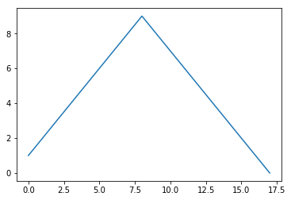

```python
plt.figure
plt.plot([1,2,3,4,5,6,7,8,9,8,7,6,5,4,3,2,1,0])
plt.show()
```

아주 간단하게 그래프를 그려 보았습니다. plot 함수에는 그래프에 표현될 데이터들이 들어가고, 각 x축과 y축은 임의로 지정되어서 숫자가 표시됩니다.  
조금 더 복잡하게 삼각함수 그래프를 그려보겠습니다. 물론 numpy를 활용합니다

```python
t = np.arange(0,12,0.01) # 0부터 12 까지 0.01 간격으로 데이터 생성하기
y = np.sin(t) # 발생시킨 데이터를 sin값으로 사용하기
```

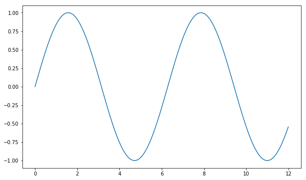

```python
plt.figure(figsize=(10,6)) # figsize: 그림 크기
plt.plot(t,y) #사용할 데이터 세팅하기
plt.show()
```

각종 옵션으로 grid나 x축, y축 라벨을 붙여 보겠습니다.

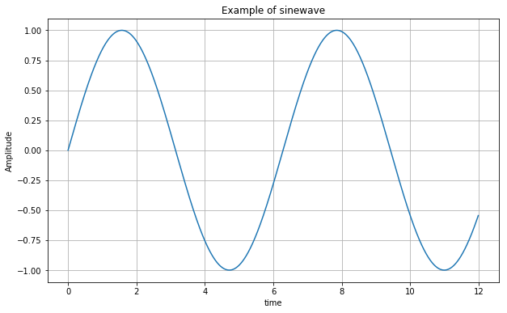

```python
plt.figure(figsize=(10, 6))
plt.plot(t, y) # 사용할 데이터 세팅
plt.grid() # 그리드 그리기
plt.xlabel('time') #x축 라벨 붙이기
plt.ylabel('Amplitude') #y축 라벨 붙이기
plt.title('Example of sinewave') # 그래프 제목 붙이기
plt.show()
```

두개 이상의 그래프를 하나의 화면에 그려낼 수도 있습니다. plot만 더 추가 해 주면 됩니다.

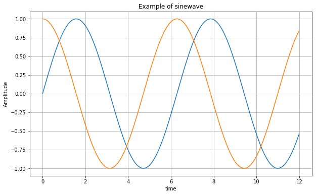

```python
plt.figure(figsize=(10, 6))
plt.plot(t, np.sin(t))
plt.plot(t, np.cos(t)) # cos 그래프 추가
plt.grid()
plt.xlabel('time')
plt.ylabel('Amplitude')
plt.title('Example of sinewave')
plt.show()
```

범례 옵션도 plot 함수에 추가 해주면 범례 표현도 가능 합니다.

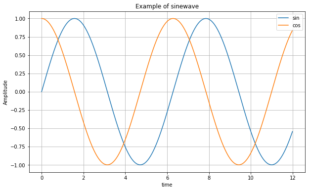

```python
plt.figure(figsize=(10, 6))
plt.plot(t, np.sin(t), label='sin') # sin 범례 추가
plt.plot(t, np.cos(t), label='cos') # cos 범례 추가
plt.grid()
plt.legend()   # 범례 보여주기
plt.xlabel('time')
plt.ylabel('Amplitude')
plt.title('Example of sinewave')
plt.show()
```

또한 lw 옵션을 이용해 선의 굵기를 지정 할 수 있고, color 옵션으로 색상도 지정 가능합니다

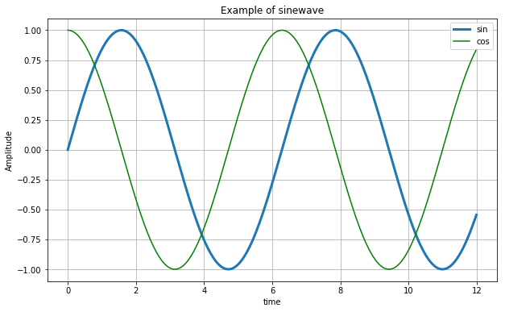

```python
plt.figure(figsize=(10, 6))
plt.plot(t, np.sin(t), lw=3 ,label='sin') # 선굵기 설정
plt.plot(t, np.cos(t), color='g', label='cos') # 색상 설정('g' : 초록색)
plt.grid()
plt.legend()   # 범례 보여주기
plt.xlabel('time')
plt.ylabel('Amplitude')
plt.title('Example of sinewave')
plt.show()
```

다른 모양 그래프로 더 알아 보겠습니다. linstyle 옵션으로 선의 모양도 지정 할 수 있습니다.

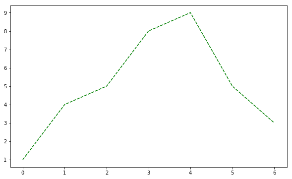

```python
t = [0,1,2,3,4,5,6]
y = [1,4,5,8,9,5,3]
plt.figure(figsize=(10, 6))
plt.plot(t,y,color='green', linestyle='dashed') # dotted : 점, dahsed : 끊어진 선
plt.show()
```

데이터가 실제 존재 하는 곳에 점을 찍어 줄 수도 있습니다.  
**marker** 옵션을 이용해 점을 찍고, **markerfacecolor** 옵션을 이용해 색상을, **markersize** 옵션으로 크기를 지정 할 수 있습니다.

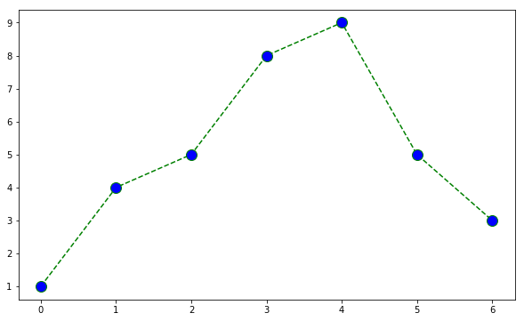

```python
t = [0,1,2,3,4,5,6]
y = [1,4,5,8,9,5,3]
plt.figure(figsize=(10, 6))
plt.plot(t,y,color='green', linestyle='dashed', marker='o', markerfacecolor='blue', markersize=12) #마커 꾸며주기 추가
plt.show()
```

**scatter**를 사용하면 점 그래프가 됩니다

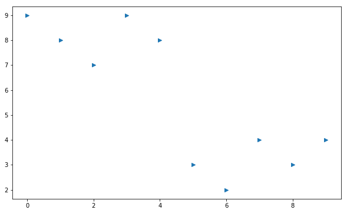

```python
t = np.array([0,1,2,3,4,5,6,7,8,9])
y = np.array([9,8,7,9,8,3,2,4,3,4])
plt.figure(figsize=(10, 6))
plt.scatter(t,y, marker='>') #scatter로 점 그래프 그리기
plt.show()
```

**scatter**에서는 마커의 크기를 **s 옵션**으로 조절합니다.  
**c 옵션(색상)**으로 color map까지 만들어 낼 수 있습니다.

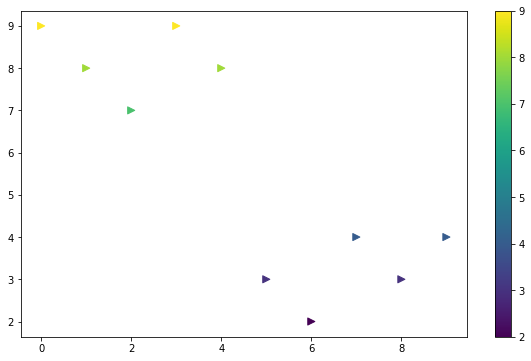

```python
colormap = y # y 값에 따라서 colormap 지정해주기

plt.figure(figsize=(10, 6))
plt.scatter(t,y,s=50, c = colormap, marker='>')
plt.colorbar() #색상 바 보여주기
plt.show()
```

numpy의 랜덤함수를 이용해서 그래프를 그려 보겠습니다.  
loc 옵션으로 평균을, scale 옵션으로 표준 편차를 조절 할 수 있습니다.

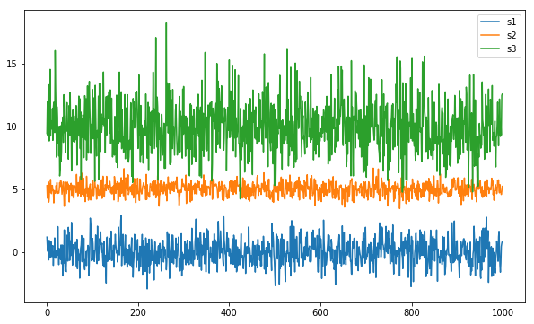

```python
s1 = np.random.normal(loc=0, scale=1, size=1000)
s2 = np.random.normal(loc=5, scale=0.5, size=1000)
s3 = np.random.normal(loc=10, scale=2, size=1000)

plt.figure(figsize=(10, 6))
plt.plot(s1, label='s1')
plt.plot(s2, label='s2')
plt.plot(s3, label='s3')
plt.legend()
plt.show()
```

위의 그래프를 boxplot으로 표현할 수도 있습니다. boxplot은 나중에 더 자세히 살펴볼 수 있습니다.

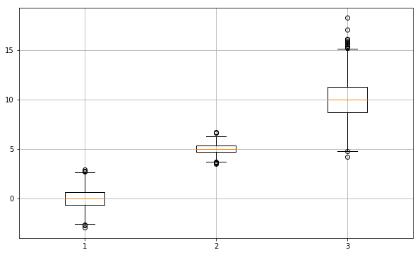

```python
plt.figure(figsize=(10, 6))
plt.boxplot((s1,s2,s3))
plt.grid()
plt.show()
```